# R class final report

R11241203 Berrica & R11241206 Leonie

2022-12-30

Data set: Systematic global assessment of reef fish communities by the Reef Life Survey program.

## **Introduction**

- This report uses worldwide data collected by volunteer (or ‘citizen’) scientists and professional biologists under the Reef Life Survey (RLS) program to make up for the disadvantage of the past studies about limited collection of broad-scale quantitative biodiversity datasets.
- The program started in 2007 and the surveys around Australia are more complete. Thus, we use those data around Australia from 2008 to 2013.
- In our opinion, reef fish abundance might be impacted by three factors that we can find in this data set. They are latitude, depth, and season.
- With this global data set about reef fish communities, we have three hypotheses:
  1. From low latitude to high latitude, reef fish abundance will gradually decrease in each region.
  2. Reef fish abundance will alter along the depth gradient in each region.
  3. Reef fish abundance will have seasonal changes influenced by primary production that change along the different seasons.

## **Methodology**

### **A. Survey methods**

The method of surveys is an underwater visual census (UVC) by SCUBA divers along a depth contour on hard substrate through a 50m transect. Divers swim along the transect and record all fish species observed within 5m of the transect on a waterproof datasheet.

```r
#Load data from IMOS-National Reef Monitoring Network Sub-Facility
library(tidyverse)
reef.fish <- read.csv('RLSreeffishdataset.csv')
reef.fish.Aus <- reef.fish %>% filter(Country == 'Australia')
```

```r
#Subset data
library(plotrix) #package to count error bar
reef.fish.Aus.se <- reef.fish.Aus  %>% group_by(Ecoregion) %>% summarise(std.er = std.error(Total)) #count error bar
reef.fish.Aus.lat <- reef.fish.Aus %>% group_by(Ecoregion) %>% summarise(meanlat = mean(SiteLat), meanlong = mean(SiteLong))
reef.fish.Aus.re <- reef.fish.Aus %>% group_by(Ecoregion) %>% summarise(mean = mean(Total)) %>%
  left_join(., reef.fish.Aus.lat, by = 'Ecoregion') %>% arrange(., desc(meanlat)) #arrange from low latitude to high
reef.fish.Aus.re$Ecoregion <- factor(reef.fish.Aus.re$Ecoregion, levels = unique(reef.fish.Aus.re$Ecoregion))
```

**Sample regions**

[output not shown]

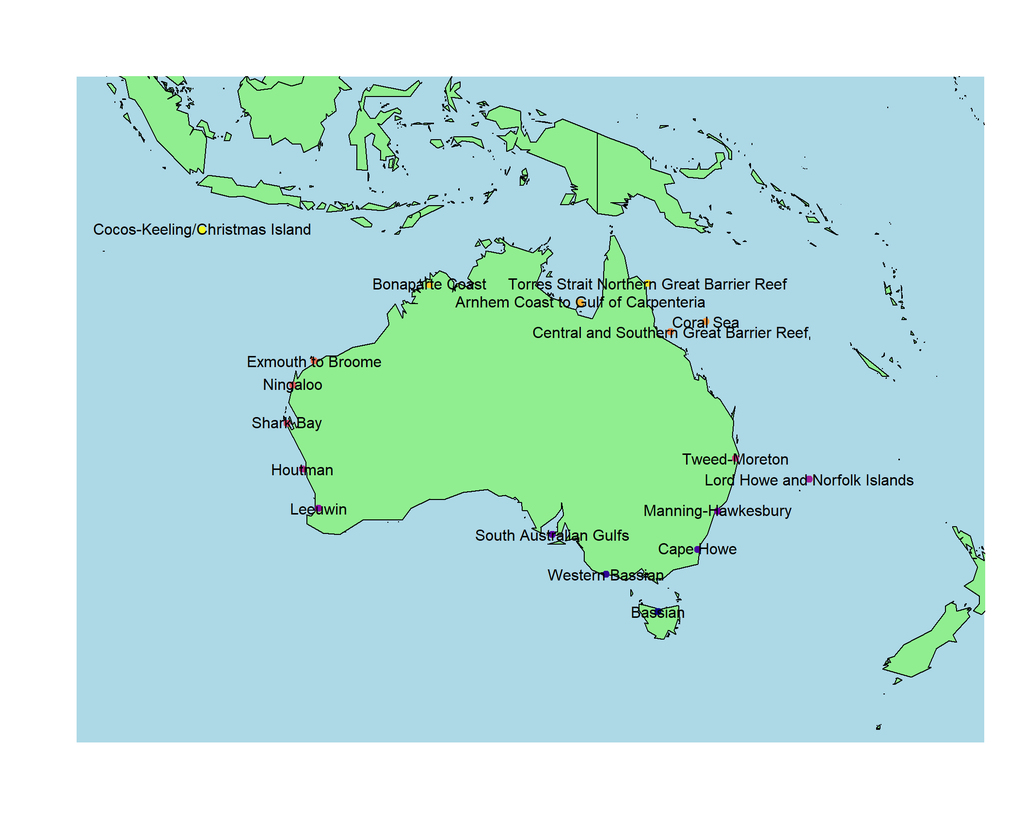

### **B. Data analyses**

First of all, we use Shapiro test to test normality of the dataset. Next, we use Kruskal test to see the significant difference between each group abundance in Ecoregion, Depth, and Month. Lastly, we use pairwise Wilcox test to see the differentiation of group abundance. The final results are presented in the bar plots.

**Latitudinal effect**  
We check the variation of reef fish abundance along latitude and divided them into two parts– western Australia and eastern Australia. Because reefs are normally better developed in the western ocean (Kinsey and Davies 1979, Wellington and Glynn 1983), we assume that reef fish abundance will increase with the reef-developed level.

**Bathymetric effect**  
In correlation between reef fish abundance and the depth gradient, we define sample depths above 10m as ‘shallow’ and other sample depths below 20m as ‘deep’. Reef fish abundance will alter along the depth gradient by altering light, salinity, temperature, and so on. Thus, we want to check the trend of altering reef fish abundance through depth.

**Seasonal effect**  
Seasonal changes can usually be observed in many biological processes so we assume that reef fish abundance will also be influenced. To see the impact, we analyzed the correlation between reef fish abundance and the season.

## **Results**

#### **Latitudinal effect**

We do not see any pattern in reef fish abundance with the latitudinal gradient. In all locations in Australia, there are significant between some sites but we can not find a trend through the latitude. In addition, we grouped the samples by location, respectively in western Australia and eastern Australia. However, there is no trend to show differentiation in reef fish abundance through the latitudinal gradient in western or eastern Australia.

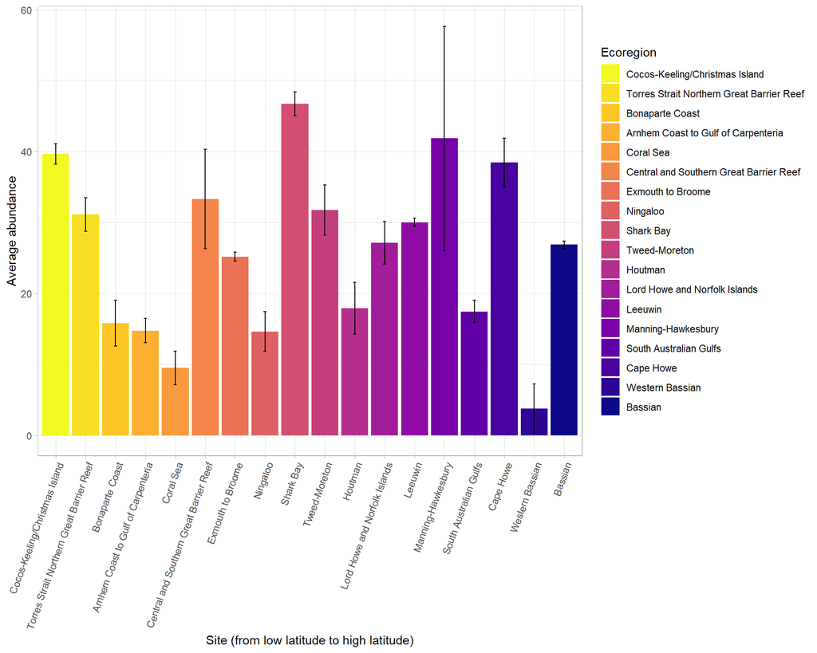

```r
# Overall data-Latitudinal----
library(ggplot2)
library(RColorBrewer)
ggplot(reef.fish.Aus.re, aes(x = Ecoregion, y = mean))+
  geom_bar(stat = "identity", aes(fill = Ecoregion))+
  geom_errorbar(aes(x = Ecoregion,
                    ymin = mean-reef.fish.Aus.se$std.er ,
                    ymax = mean+reef.fish.Aus.se$std.er),
                width=.1)+
  theme_light()+
  theme(axis.text.x = element_text(angle=70, hjust=1, vjust=1))+
  labs(x = 'Site (from low latitude to high latitude)', y = 'Average abundance')+
  scale_fill_viridis(discrete = T, option = 'plasma',direction = -1)
```

**East**

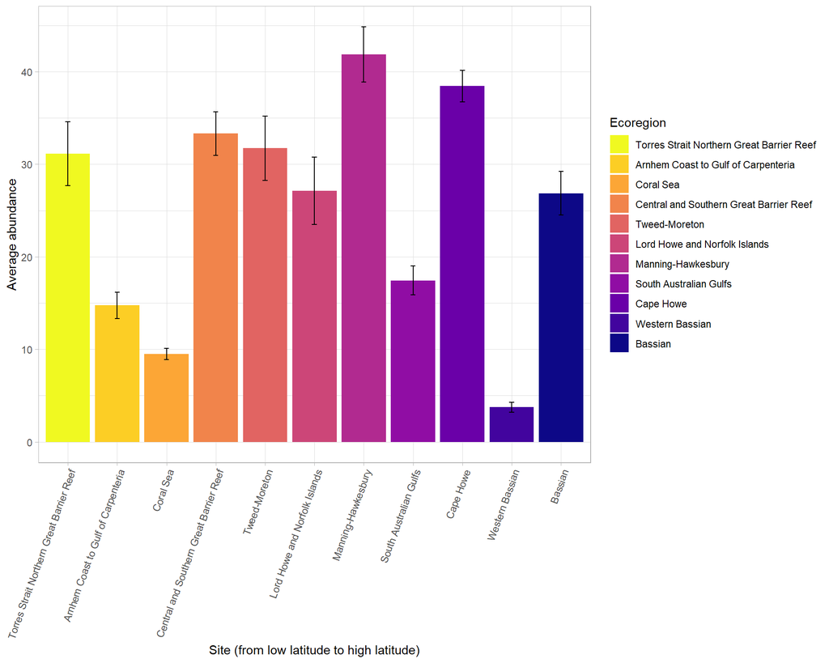

```r
#West and East----
#Latitude
reef.fish.Aus.re.W_E <- reef.fish.Aus.re %>% data.frame(Side = rep('East',18))
reef.fish.Aus.re.W_E$Side[c(1,3,7,8,9,11,13)] <- rep('West',7)
reef.fish.Aus.re.W_E <- reef.fish.Aus.re.W_E %>% group_by(Side) %>% arrange(., desc(meanlat), .by_group = T)
reef.fish.Aus.re.W_E <- full_join(reef.fish.Aus.re.W_E, reef.fish.Aus.se, by = 'Ecoregion')
reef.fish.Aus.re.W_E$Ecoregion <- factor(reef.fish.Aus.re.W_E$Ecoregion, levels = unique(reef.fish.Aus.re.W_E$Ecoregion))

reef.fish.Aus.re.E <- reef.fish.Aus.re.W_E %>% filter(Side == 'East')


#plot only for east
ggplot(reef.fish.Aus.re.E, aes(x = Ecoregion, y = mean))+
  geom_bar(stat = "identity", aes(fill = Ecoregion))+
  geom_errorbar(aes(x = Ecoregion,
                    ymin = mean-std.er ,
                    ymax = mean+std.er),
                width=.1)+
  theme_light()+
  theme(axis.text.x = element_text(angle=70, hjust=1, vjust=1))+
  labs(x = 'Site (from low latitude to high latitude)', y = 'Average abundance')+
  scale_fill_viridis(discrete = T, option = 'plasma',direction = -1)
```

**West**

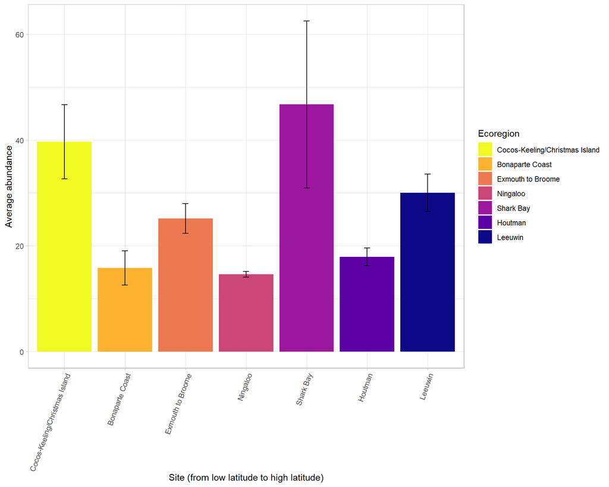

```r
reef.fish.Aus.re.W <- reef.fish.Aus.re.W_E %>% filter(Side == 'West')
#plot only for west
ggplot(reef.fish.Aus.re.W, aes(x = Ecoregion, y = mean))+
  geom_bar(stat = "identity", aes(fill = Ecoregion))+
  geom_errorbar(aes(x = Ecoregion,
                    ymin = mean-std.er ,
                    ymax = mean+std.er),
                width=.1)+
  theme_light()+
  theme(axis.text.x = element_text(angle=70, hjust=1, vjust=1))+
  labs(x = 'Site (from low latitude to high latitude)', y = 'Average abundance')+
  scale_fill_viridis(discrete = T, option = 'plasma',direction = -1)
```

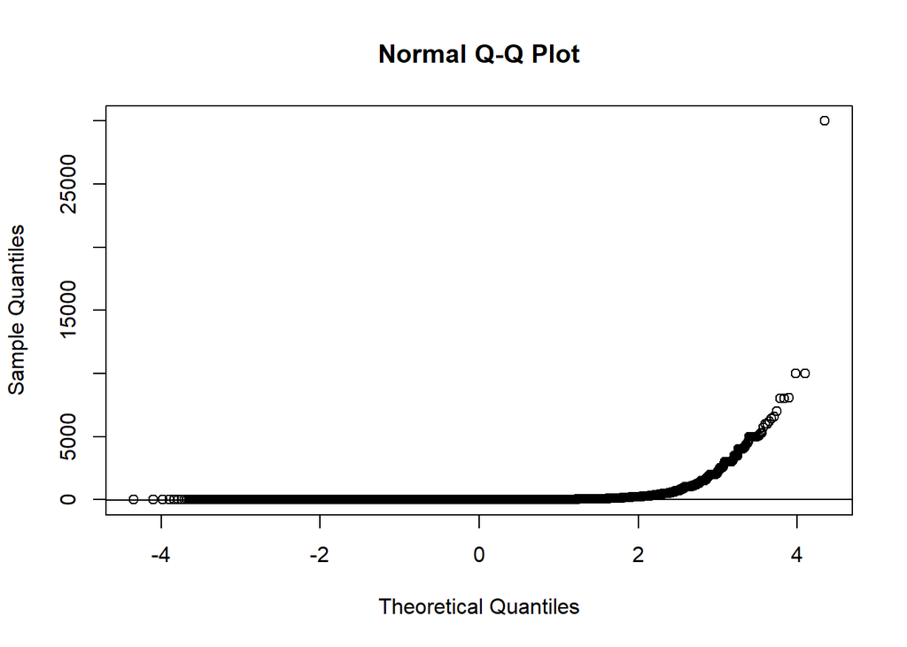

```r
#Data analysis
###Latitudinal variation----

#Shapiro

#sample size more than 5000
qqnorm(reef.fish.Aus$Total)
qqline(reef.fish.Aus$Total)
```

```r
#=> Not a normal distribution

#kruskal.test
#One-way non-parametric analysis
kruskal.test(Total ~ Ecoregion, data = reef.fish.Aus)
```

```
##
##  Kruskal-Wallis rank sum test
##
## data:  Total by Ecoregion
## Kruskal-Wallis chi-squared = 602.08, df = 17, p-value < 2.2e-16
```

```r
#Kruskal-Wallis chi-squared = 602.08, df = 17, p-value < 2.2e-16 => There are significant differences

#post-hoc tests
pairwise.wilcox.test(reef.fish.Aus$Total, reef.fish.Aus$Ecoregion,
                     p.adjust.method = "BH") #=> They are not the same, see barplot
```

```
##
##  Pairwise comparisons using Wilcoxon rank sum test with continuity correction
##
## data:  reef.fish.Aus$Total and reef.fish.Aus$Ecoregion
##
##                                           Arnhem Coast to Gulf of Carpenteria
## Bassian                                   8.7e-08
## Bonaparte Coast                           0.40731
## Cape Howe                                 0.93431
## Central and Southern Great Barrier Reef   0.05664
## Cocos-Keeling/Christmas Island            0.00037
## Coral Sea                                 2.3e-16
## Exmouth to Broome                         0.47690
## Houtman                                   0.00136
## Leeuwin                                   0.00033
## Lord Howe and Norfolk Islands             0.02592
## Manning-Hawkesbury                        0.88686
## Ningaloo                                  0.89061
## Shark Bay                                 0.46486
## South Australian Gulfs                    2.9e-07
## Torres Strait Northern Great Barrier Reef 0.12220
## Tweed-Moreton                             0.73385
## Western Bassian                           6.6e-07
##                                           Bassian Bonaparte Coast Cape Howe
## Bassian                                   -       -               -
## Bonaparte Coast                           3.0e-10 -               -
## Cape Howe                                 < 2e-16 0.35189         -
## Central and Southern Great Barrier Reef   4.6e-14 0.00258         1.0e-07
## Cocos-Keeling/Christmas Island            0.04633 5.2e-06         6.4e-08
## Coral Sea                                 7.8e-06 < 2e-16         < 2e-16
## Exmouth to Broome                         < 2e-16 0.83016         0.26449
## Houtman                                   0.00587 2.9e-05         6.2e-08
## Leeuwin                                   0.00048 3.1e-06         8.4e-15
## Lord Howe and Norfolk Islands             4.7e-12 0.00106         5.4e-10
## Manning-Hawkesbury                        < 2e-16 0.40731         0.83016
## Ningaloo                                  < 2e-16 0.42573         0.93573
## Shark Bay                                 0.00260 0.14342         0.35535
## South Australian Gulfs                    0.45405 5.4e-10         < 2e-16
## Torres Strait Northern Great Barrier Reef 6.2e-11 0.01066         0.00082
## Tweed-Moreton                             < 2e-16 0.16746         0.39336
```

[output cut: 132 more lines]

```
## Cocos-Keeling/Christmas Island            -
## Coral Sea                                 -
## Exmouth to Broome                         -
## Houtman                                   -
## Leeuwin                                   -
## Lord Howe and Norfolk Islands             -
## Manning-Hawkesbury                        -
## Ningaloo                                  -
## Shark Bay                                 -
## South Australian Gulfs                    -
## Torres Strait Northern Great Barrier Reef -
## Tweed-Moreton                             -
## Western Bassian                           6.4e-07
##
## P value adjustment method: BH
```

#### **Bathymetric effect**

Reef fish abundance represents the differentiation in shallow water in different sites. To see the effect through the depth gradient, we only have six sites with both shallow and deep data (Bassian, Cape Howe, Leeuwin, Manning-Hawkesbury, Lord Howe and Norfolk Islands, and Houtman). In these six locations, reef fish abundance seem different but non‑significant differentiation between shallow and deep depth. However, reef fish abundance tends to increase at four locations (Cape Howe, Leeuwin, Manning-Hawkesbury, and Lord Howe and Norfolk Islands) and decrease at two locations (Bassian and Houtman).

```r
#Data analysis
#shallow(<=10) and deep(>=20) water----
reef.fish.Aus.dep <- reef.fish.Aus %>% filter(reef.fish.Aus$Depth <= 10 | reef.fish.Aus$Depth>= 20) %>%
  mutate(water = ifelse(Depth <= 10,'shallow', 'deep'))
reef.fish.Aus.dep.se <-  reef.fish.Aus.dep %>% group_by(Ecoregion, water) %>% summarise(std.er = std.error(Total)) #count error bar
reef.fish.Aus.dep.lat <- reef.fish.Aus.dep %>% group_by(Ecoregion, water) %>% summarise(meanlat = mean(SiteLat), meanlong = mean(SiteLong))
reef.fish.Aus.dep.re <- reef.fish.Aus.dep %>% group_by(Ecoregion, water) %>% summarise(mean = mean(Total)) %>%
  left_join(., reef.fish.Aus.dep.lat, by = c('Ecoregion','water')) %>% arrange(., desc(meanlat)) #arrange from low latitude to high
```

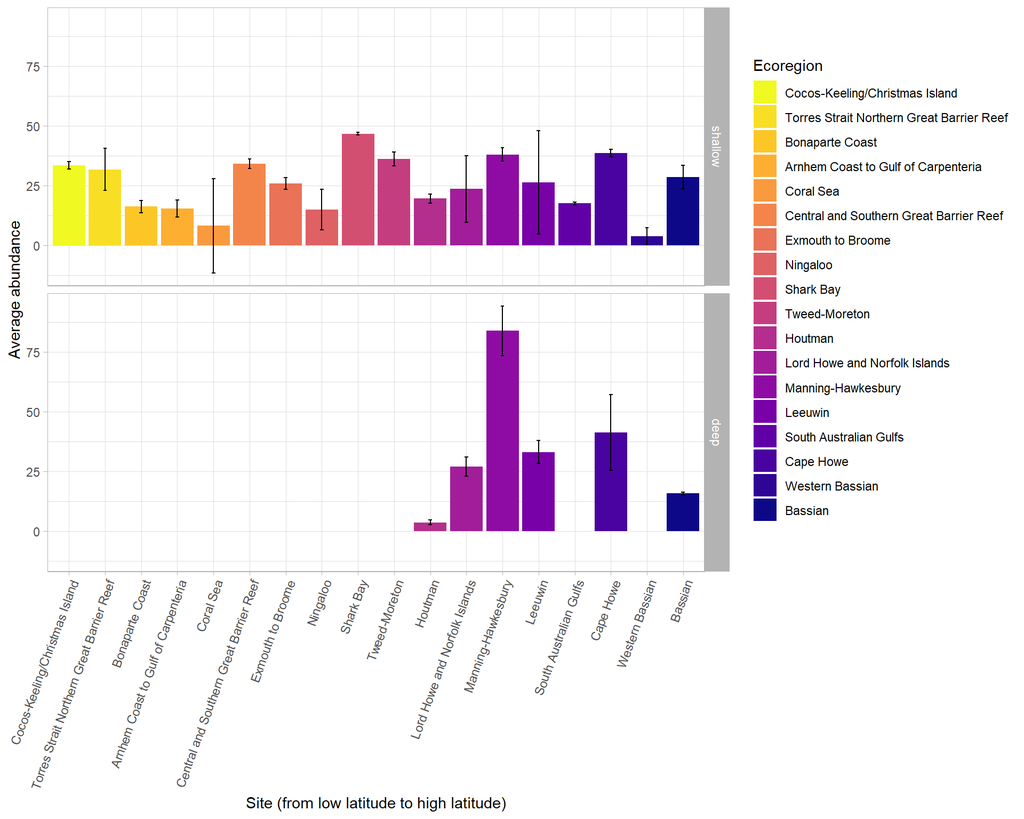

```r
reef.fish.Aus.dep.re$Ecoregion <- factor(reef.fish.Aus.dep.re$Ecoregion, levels = unique(reef.fish.Aus.dep.re$Ecoregion))
reef.fish.Aus.dep.re$water <- factor(reef.fish.Aus.dep.re$water, levels = unique(reef.fish.Aus.dep.re$water))

#plot
ggplot(reef.fish.Aus.dep.re, aes(x = Ecoregion, y = mean))+
  geom_bar(stat = "identity", aes(fill = Ecoregion))+
  geom_errorbar(aes(x = Ecoregion,
                    ymin = mean-reef.fish.Aus.dep.se$std.er ,
                    ymax = mean+reef.fish.Aus.dep.se$std.er),
                width=.1)+
  theme_light()+
  theme(axis.text.x = element_text(angle=70, hjust=1, vjust=1))+
  labs(x = 'Site (from low latitude to high latitude)', y = 'Average abundance')+
  scale_fill_viridis(discrete = T, option = 'plasma',direction = -1)+
  facet_grid(rows = vars(water))
```

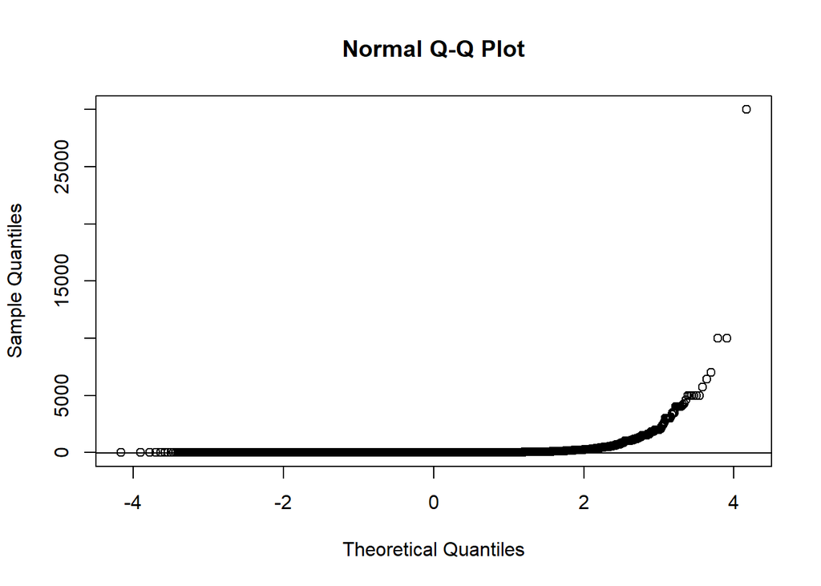

```r
##Subset those locations contain both shallow and deep samples
bothS_D <- c('Houtman','Lord Howe and Norfolk Islands','Manning-Hawkesbury','Leeuwin','Cape Howe','Bassian')
reef.fish.Aus.dep.bothS_D <- reef.fish.Aus.dep %>% filter(Ecoregion %in% bothS_D)
reef.fish.Aus.dep.bothS_D <- reef.fish.Aus.dep.bothS_D %>% mutate(Eco_water = paste(Ecoregion, water)) %>% arrange(Ecoregion)
reef.fish.Aus.dep.bothS_D$Eco_water <- factor(reef.fish.Aus.dep.bothS_D$Eco_water,
                                              levels = unique(reef.fish.Aus.dep.bothS_D$Eco_water))
#Shapiro test
#sample size more than 5000
qqnorm(reef.fish.Aus.dep.bothS_D$Total)
qqline(reef.fish.Aus.dep.bothS_D$Total)
```

```r
#=> Not a normal distribution

#kruskal.test
#One-way non-parametric analysis
kruskal.test(Total ~ Eco_water, data = reef.fish.Aus.dep.bothS_D)
```

```
##
##  Kruskal-Wallis rank sum test
##
## data:  Total by Eco_water
## Kruskal-Wallis chi-squared = 198.81, df = 11, p-value < 2.2e-16
```

```r
#Kruskal-Wallis chi-squared = 198.81, df = 11, p-value < 2.2e-16 => There are significant differences

#post-hoc tests
pairwise.wilcox.test(reef.fish.Aus.dep.bothS_D$Total, reef.fish.Aus.dep.bothS_D$Eco_water,
                     p.adjust.method = "BH")
```

```
##
##  Pairwise comparisons using Wilcoxon rank sum test with continuity correction
##
## data:  reef.fish.Aus.dep.bothS_D$Total and reef.fish.Aus.dep.bothS_D$Eco_water
##
##                                       Bassian shallow Bassian deep
## Bassian deep                          0.7345          -
## Cape Howe shallow                     < 2e-16         0.3950
## Cape Howe deep                        0.8612          0.7589
## Houtman shallow                       0.0079          0.5558
## Houtman deep                          0.3210          0.7466
## Leeuwin shallow                       0.0846          0.6192
## Leeuwin deep                          0.4706          0.4756
## Lord Howe and Norfolk Islands shallow 4.9e-09         0.4756
## Lord Howe and Norfolk Islands deep    0.8945          0.7054
## Manning-Hawkesbury deep               0.0072          0.4706
## Manning-Hawkesbury shallow            < 2e-16         0.3950
##                                       Cape Howe shallow Cape Howe deep
## Bassian deep                          -                 -
## Cape Howe shallow                     -                 -
## Cape Howe deep                        0.7408            -
## Houtman shallow                       4.6e-05           0.9715
## Houtman deep                          0.0628            0.4756
## Leeuwin shallow                       2.0e-14           0.9703
## Leeuwin deep                          0.9715            0.7862
## Lord Howe and Norfolk Islands shallow 5.9e-08           0.9269
## Lord Howe and Norfolk Islands deep    0.0654            0.8423
## Manning-Hawkesbury deep               0.4760            0.8423
## Manning-Hawkesbury shallow            0.7249            0.7468
##                                       Houtman shallow Houtman deep
## Bassian deep                          -               -
## Cape Howe shallow                     -               -
## Cape Howe deep                        -               -
## Houtman shallow                       -               -
## Houtman deep                          0.1494          -
## Leeuwin shallow                       0.3953          0.2003
## Leeuwin deep                          0.7054          0.1668
## Lord Howe and Norfolk Islands shallow 0.4831          0.1057
## Lord Howe and Norfolk Islands deep    0.4356          0.3950
## Manning-Hawkesbury deep               0.3950          0.1005
```

[output cut: 36 more lines]

```
## Manning-Hawkesbury shallow            0.0846
##                                       Manning-Hawkesbury deep
## Bassian deep                          -
## Cape Howe shallow                     -
## Cape Howe deep                        -
## Houtman shallow                       -
## Houtman deep                          -
## Leeuwin shallow                       -
## Leeuwin deep                          -
## Lord Howe and Norfolk Islands shallow -
## Lord Howe and Norfolk Islands deep    -
## Manning-Hawkesbury deep               -
## Manning-Hawkesbury shallow            0.5923
##
## P value adjustment method: BH
```

#### **Seasonal effect**

```r
#Separate by date(month)----
reef.fish.Aus.dat <- reef.fish.Aus %>% mutate(Month = sapply(strsplit(reef.fish.Aus$SurveyDate,'-'), '[', 2)) #split the character of month

reef.fish.Aus.dat.se <-  reef.fish.Aus.dat %>% group_by(Ecoregion, Month) %>% summarise(std.er = std.error(Total)) #count error bar
reef.fish.Aus.dat.lat <- reef.fish.Aus.dat %>% group_by(Ecoregion, Month) %>% summarise(meanlat = mean(SiteLat), meanlong = mean(SiteLong))
reef.fish.Aus.dat.re <- reef.fish.Aus.dat %>% group_by(Ecoregion, Month) %>% summarise(mean = mean(Total)) %>%
  left_join(., reef.fish.Aus.dat.lat, by = c('Ecoregion', 'Month')) %>% arrange(., desc(meanlat)) #arrange from low latitude to high
```

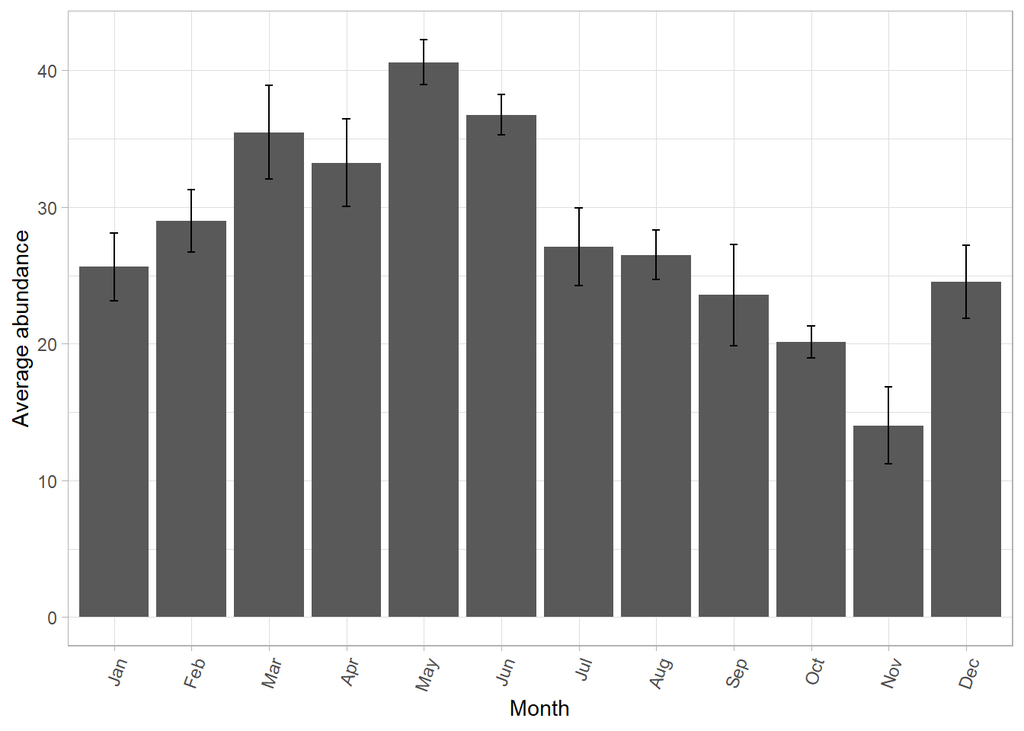

```r
reef.fish.Aus.dat.re$Ecoregion <- factor(reef.fish.Aus.dat.re$Ecoregion, levels = unique(reef.fish.Aus.dat.re$Ecoregion))
reef.fish.Aus.dat.re <- reef.fish.Aus.dat.re %>%
  mutate(Month = factor(Month, levels = month.abb)) %>% arrange(Month)
reef.fish.Aus.dat <- reef.fish.Aus %>% mutate(Month = sapply(strsplit(reef.fish.Aus$SurveyDate,'-'), '[', 2)) #split the character of month
reef.fish.Aus.dat.se.onM <-  reef.fish.Aus.dat %>% group_by(Month) %>% summarise(std.er = std.error(Total)) #count error bar
reef.fish.Aus.dat.onM <- reef.fish.Aus.dat %>% group_by(Month) %>% summarise(mean = mean(Total))
reef.fish.Aus.dat.onM <- reef.fish.Aus.dat.onM %>%
  mutate(Month = factor(Month, levels = month.abb)) %>% arrange(Month)

ggplot(reef.fish.Aus.dat.onM, aes(x = Month, y = mean))+
  geom_bar(stat = "identity")+
  geom_errorbar(aes(x = Month,
                    ymin = mean-reef.fish.Aus.dat.se.onM$std.er ,
                    ymax = mean+reef.fish.Aus.dat.se.onM$std.er),
                width=.1)+
  theme_light()+
  theme(axis.text.x = element_text(angle=70, hjust=1, vjust=1))+
  labs(x = 'Month', y = 'Average abundance')+
  scale_fill_viridis(discrete = T, option = 'plasma',direction = -1)
```

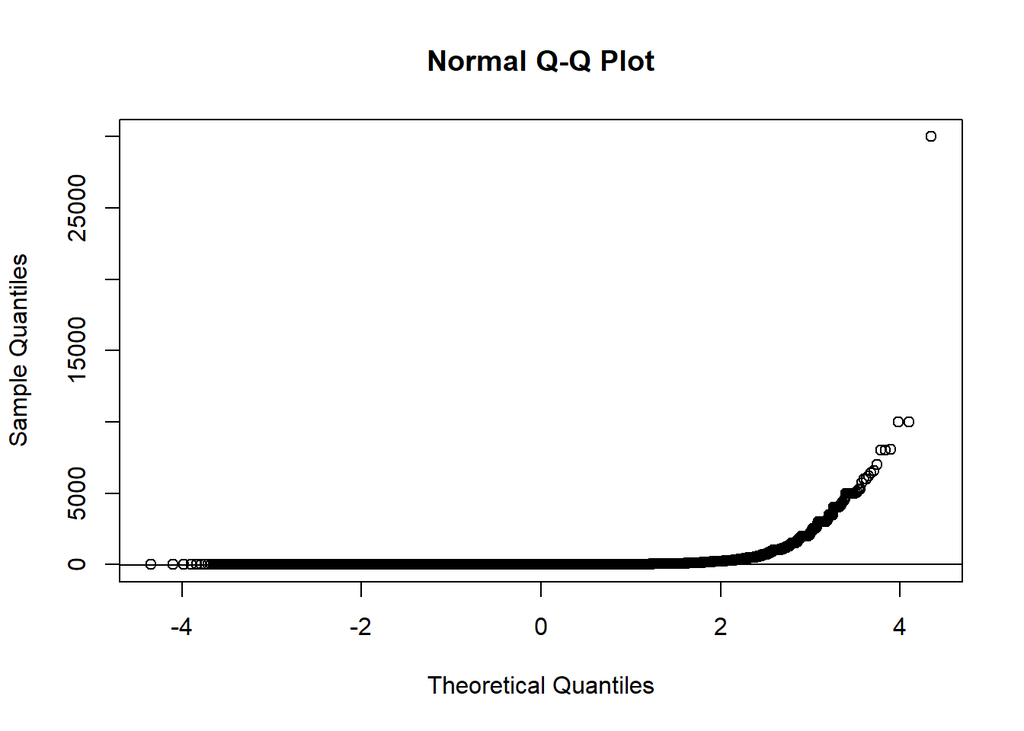

```r
#Data analysis
###Month variation----

#Shapiro
#sample size more than 5000
qqnorm(reef.fish.Aus.dat$Total)
qqline(reef.fish.Aus.dat$Total)
```

```r
#=> Not a normal distribution

#kruskal.test
#One-way non-parametric analysis
kruskal.test(Total ~ Month, data = reef.fish.Aus.dat)
```

```
##
##  Kruskal-Wallis rank sum test
##
## data:  Total by Month
## Kruskal-Wallis chi-squared = 346.34, df = 11, p-value < 2.2e-16
```

```r
#Kruskal-Wallis chi-squared = 346.34, df = 11, p-value < 2.2e-16 => There are significant differences


#post-hoc tests
reef.fish.Aus.dat.arranMon <- reef.fish.Aus.dat %>%
  mutate(Month = factor(Month, levels = month.abb)) %>% arrange(Month)

pairwise.wilcox.test(reef.fish.Aus.dat.arranMon$Total, reef.fish.Aus.dat.arranMon$Month,
                     p.adjust.method = "BH") #=> They are not the same, see barplot
```

```
##
##  Pairwise comparisons using Wilcoxon rank sum test with continuity correction
##
## data:  reef.fish.Aus.dat.arranMon$Total and reef.fish.Aus.dat.arranMon$Month
##
##     Jan     Feb     Mar     Apr     May     Jun     Jul     Aug     Sep
## Feb 0.02272 -       -       -       -       -       -       -       -
## Mar 5.4e-06 2.3e-14 -       -       -       -       -       -       -
## Apr 0.04861 0.99998 7.2e-11 -       -       -       -       -       -
## May 1.1e-07 4.0e-16 0.25781 1.1e-12 -       -       -       -       -
## Jun 2.1e-10 < 2e-16 0.07042 < 2e-16 0.62401 -       -       -       -
## Jul 5.6e-10 < 2e-16 0.26776 < 2e-16 0.76543 0.34135 -       -       -
## Aug 0.12324 0.00090 0.14729 0.00240 0.02820 0.00684 0.02511 -       -
## Sep 0.00018 0.01893 5.6e-14 0.03670 3.2e-16 < 2e-16 < 2e-16 7.4e-06 -
## Oct 1.4e-06 0.00071 < 2e-16 0.00192 < 2e-16 < 2e-16 < 2e-16 1.6e-07 0.29997
## Nov 0.07321 0.73441 9.4e-07 0.73441 2.6e-08 5.6e-10 2.3e-09 0.00467 0.14729
## Dec 0.00422 6.2e-07 0.59379 6.1e-06 0.15247 0.05015 0.16069 0.43788 1.7e-09
##     Oct     Nov
## Feb -       -
## Mar -       -
## Apr -       -
## May -       -
## Jun -       -
## Jul -       -
## Aug -       -
## Sep -       -
## Oct -       -
## Nov 0.03201 -
## Dec 3.6e-11 0.00011
##
## P value adjustment method: BH
```